# Least Squares Regression

Alan T. Arnholt

9/8/2020

# 1 Correlation

The **correlation coefficient**, denoted by $r$, measures the direction and strength of the linear relationship between two numerical variables. Is is given by the equation

$$\begin{equation}
r = \frac{1}{(n-1)}\sum_{i=1}^n\left(\frac{x_i - \bar{x}}{s_x}\right)\left(\frac{y_i - \bar{y}}{s_y}\right)
\tag{1.1}
\end{equation}$$

Following are the high school GPAs and the college GPAs at the end of the freshman year for ten different students from the `Gpa` data set of the `BSDA` package.

| hsgpa | collgpa |
| --- | --- |
| 2.7 | 2.2 |
| 3.1 | 2.8 |
| 2.1 | 2.4 |
| 3.2 | 3.8 |
| 2.4 | 1.9 |
| 3.4 | 3.5 |
| 2.6 | 3.1 |
| 2.0 | 1.4 |
| 3.1 | 3.4 |
| 2.5 | 2.5 |

Create a scatterplot and then comment on the relationship between the two variables.

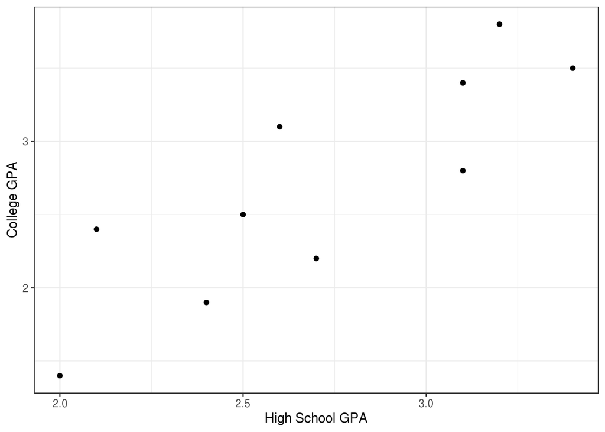

Figure 1.1: Scatterplot of College GPA versus High School GPA

```r
library(tidyverse)
library(BSDA)
ggplot(data = Gpa, aes(x = hsgpa, y = collgpa)) +
  labs(x = "High School GPA", y = "College GPA") +
  geom_point() +
  theme_bw()
```

The college GPA is the response variable and is labeled on the vertical axis. The scatterplot in Figure 1.1 shows that the college GPA increases as the high school GPA increases. In fact, the the dots appear to cluster along a straight line. The correlation coefficient is $r = 0.844$, which indicates that a straight line is a reasonable relationship between the two variables.

- Compute the correlation coefficient using (1.1).

```r
head(Gpa)
```

```
# A tibble: 6 x 2
  hsgpa collgpa
  <dbl>   <dbl>
1   2.7     2.2
2   3.1     2.8
3   2.1     2.4
4   3.2     3.8
5   2.4     1.9
6   3.4     3.5
```

```r
values <- Gpa %>%
  mutate(y_ybar = collgpa - mean(collgpa), x_xbar = hsgpa - mean(hsgpa), zx = x_xbar/sd(hsgpa), zy = y_ybar/sd(collgpa))
values
```

```
# A tibble: 10 x 6
   hsgpa collgpa y_ybar  x_xbar      zx     zy
   <dbl>   <dbl>  <dbl>   <dbl>   <dbl>  <dbl>
 1   2.7     2.2 -0.5   -0.0100 -0.0210 -0.657
 2   3.1     2.8  0.100  0.39    0.817   0.131
 3   2.1     2.4 -0.3   -0.610  -1.28   -0.394
 4   3.2     3.8  1.10   0.49    1.03    1.44
 5   2.4     1.9 -0.8   -0.31   -0.650  -1.05
 6   3.4     3.5  0.800  0.69    1.45    1.05
 7   2.6     3.1  0.400 -0.110  -0.231   0.525
 8   2       1.4 -1.3   -0.71   -1.49   -1.71
 9   3.1     3.4  0.700  0.39    0.817   0.919
10   2.5     2.5 -0.2   -0.210  -0.440  -0.263
```

```r
#
values %>%
  summarize(r = (1/9)*sum(zx*zy))
```

```
# A tibble: 1 x 1
      r
  <dbl>
1 0.844
```

Using the build in `cor()` function:

```r
Gpa %>%
  summarize(r = cor(collgpa, hsgpa))
```

```
# A tibble: 1 x 1
      r
  <dbl>
1 0.844
```

Note:

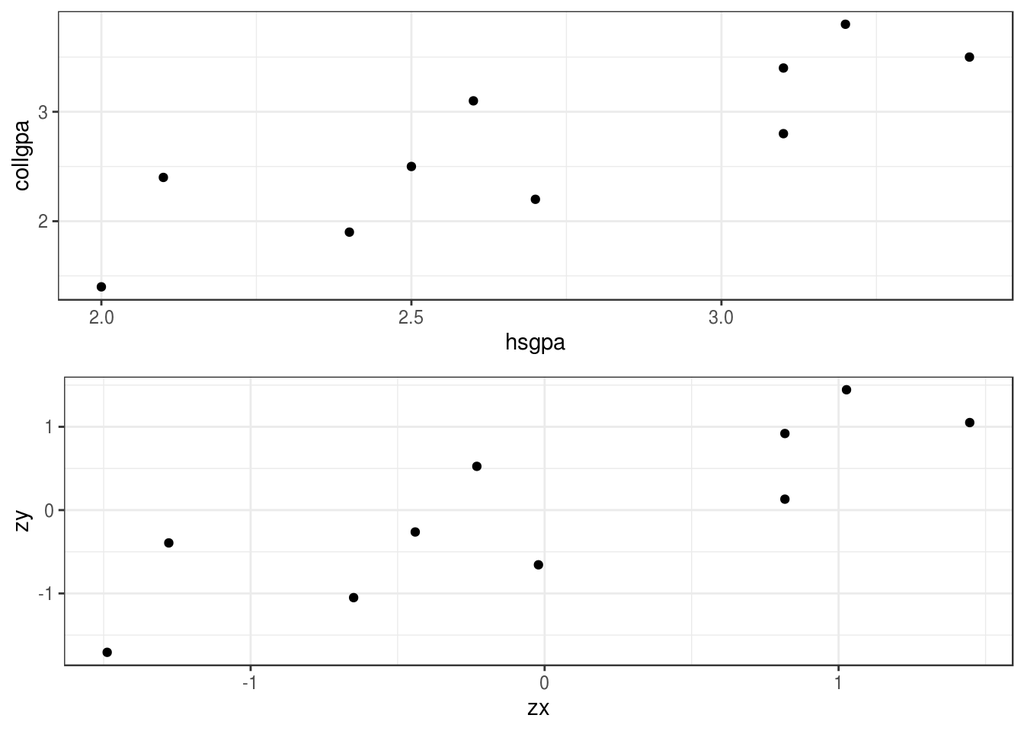

```r
p1 <- ggplot(data = Gpa, aes(x = hsgpa, y = collgpa)) +
  geom_point() +
  theme_bw()
p2 <- ggplot(data = values, aes(x = zx, y = zy)) +
  geom_point() +
  theme_bw()
library(gridExtra)
grid.arrange(p1, p2, ncol = 1, nrow = 2)
```

# 2 Least Squares Regression

The equation of a straight line is

$$y = b_0 + b_1x$$

where $b_0$ is the $y$-intercept and $b_1$ is the slope of the line. From the equation of the line that best fits the data,

$$\hat{y} = b_0 + b_1x$$

we can compute a predicted $y$ for each value of $x$ and then measure the error of the prediction. The error of the prediction, $e_i$ (also called the residual) is the difference in the actual $y_i$ and the predicted $\hat{y}_i$. That is, the residual associated with the data point $(x_i, y_i)$ is

$$e_i = y_i - \hat{y}_i.$$

The least squares regression line is

$$\hat{y} = b_0 + b_1x$$

where

$$\begin{equation}
b_1 = \frac{\sum(x_i - \bar{x})(y_i - \bar{y})}{\sum(x_i - \bar{x})^2} = r\frac{s_y}{s_x}
\tag{2.1}
\end{equation}$$

and

$$\begin{equation}
b_0 = \bar{y} - b_1\bar{x}
\tag{2.2}
\end{equation}$$

Find the least squares regression line $\hat{y} = b_0 + b_1x$ for the `Gpa` data.

```r
Gpa %>%
  summarize(b1 = cor(hsgpa, collgpa)*sd(collgpa)/sd(hsgpa),
            b0 = mean(collgpa) - b1*mean(hsgpa))
```

```
# A tibble: 1 x 2
     b1     b0
  <dbl>  <dbl>
1  1.35 -0.950
```

The coefficients are also computed when using the `lm()` function.

```r
mod1 <- lm(collgpa ~ hsgpa, data = Gpa)
mod1
```

```
Call:
lm(formula = collgpa ~ hsgpa, data = Gpa)

Coefficients:
(Intercept)        hsgpa
    -0.9504       1.3470
```

```r
summary(mod1)
```

```
Call:
lm(formula = collgpa ~ hsgpa, data = Gpa)

Residuals:
     Min       1Q   Median       3Q      Max
-0.48653 -0.37273 -0.02328  0.37365  0.54817

Coefficients:
            Estimate Std. Error t value Pr(>|t|)
(Intercept)  -0.9504     0.8318  -1.143  0.28625
hsgpa         1.3470     0.3027   4.449  0.00214 **
---
Signif. codes:  0 '***' 0.001 '**' 0.01 '*' 0.05 '.' 0.1 ' ' 1

Residual standard error: 0.4333 on 8 degrees of freedom
Multiple R-squared:  0.7122,    Adjusted R-squared:  0.6762
F-statistic:  19.8 on 1 and 8 DF,  p-value: 0.002141
```

```r
library(moderndive)
get_regression_table(mod1)
```

```
# A tibble: 2 x 7
  term      estimate std_error statistic p_value lower_ci upper_ci
  <chr>        <dbl>     <dbl>     <dbl>   <dbl>    <dbl>    <dbl>
1 intercept    -0.95     0.832     -1.14   0.286   -2.87     0.968
2 hsgpa         1.35     0.303      4.45   0.002    0.649    2.04
```

Find the residuals for `mod1`.

```r
get_regression_points(mod1)
```

```
# A tibble: 10 x 5
      ID collgpa hsgpa collgpa_hat residual
   <int>   <dbl> <dbl>       <dbl>    <dbl>
 1     1     2.2   2.7        2.69   -0.487
 2     2     2.8   3.1        3.22   -0.425
 3     3     2.4   2.1        1.88    0.522
 4     4     3.8   3.2        3.36    0.44
 5     5     1.9   2.4        2.28   -0.382
 6     6     3.5   3.4        3.63   -0.129
 7     7     3.1   2.6        2.55    0.548
 8     8     1.4   2          1.74   -0.344
 9     9     3.4   3.1        3.22    0.175
10    10     2.5   2.5        2.42    0.083
```

Add the least squares line to the scatterplot for `collgpa` versus `hsgpa`.

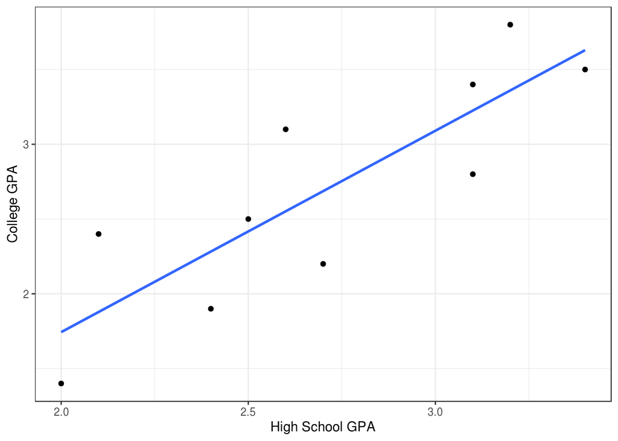

```r
ggplot(data = Gpa, aes(x = hsgpa, y = collgpa)) +
  geom_point() +
  geom_smooth(method = "lm", se = FALSE) +
  labs(x = "High School GPA", y = "College GPA") +
  theme_bw()
```

## 2.1 Assessing the fit

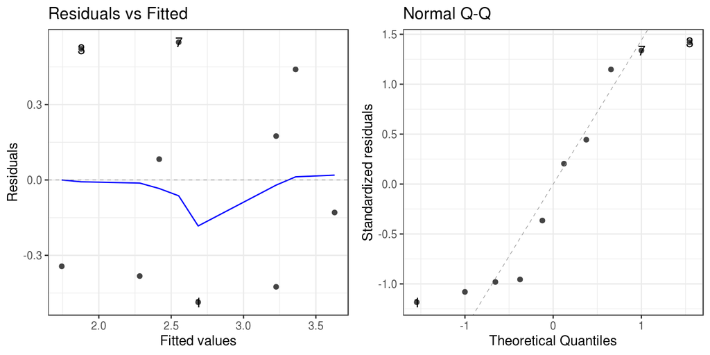

```r
library(ggfortify)
autoplot(mod1, ncol = 2, nrow = 1, which = 1:2) + theme_bw()
```